# LoanTap Personal Loan - Credit Underwriting Case Study

## 1. Business problem statement and objective

LoanTap provides instant and flexible credit solution to millenials.

### Objective

- Predict personal loan should be approved
- Recommend REPAYMENT RISK POSTURE using a probablistic model

For personal loans, incorrect credit decision can result in

- False posivives = Approving risky borrowers
- False negatives = Rejecting safe borrowers

### Target Variable ( loan_status )

- 1 = fully paid
- 0 = default / charged off

## 2. Import libraries and dataset

```python
import pandas as pd
import numpy as np

import matplotlib.pyplot as plt
import seaborn as sns

from sklearn.preprocessing import MinMaxScaler, StandardScaler
from sklearn.model_selection import train_test_split
from sklearn.linear_model import LogisticRegression
from sklearn.metrics import classification_report, confusion_matrix, roc_curve, roc_auc_score, precision_recall_curve

import warnings
warnings.filterwarnings('ignore')

df = pd.read_csv('logistic_regression.csv')
```

## 3. Initial Data Understanding

```python
# Basic exploration
print("=" * 50)
print("DATA EXPLORATION SUMMARY")
print("=" * 50)

display(df.shape)
print(f"Shape: {df.shape[0]} rows, {df.shape[1]} columns")

print("\n" + "=" * 50)
print("FIRST 5 ROWS:")
print("=" * 50)
display(df.head())

print("\n" + "=" * 50)
print("LAST 5 ROWS:")
print("=" * 50)
display(df.tail())

print("\n" + "=" * 50)
print("DATA INFO:")
print("=" * 50)
display(df.info())

print("\n" + "=" * 50)
print("DESCRIPTIVE STATISTICS:")
print("=" * 50)
display(df.describe().T)

print("\n" + "=" * 50)
print("Duplicates:")
print("=" * 50)
display(df.duplicated().sum())

print("\n" + "=" * 50)
print("MISSING VALUES:")
print("=" * 50)
(pd.DataFrame({'Missing': df.isnull().sum(),'Percent': df.isnull().sum() / len(df) * 100}) .sort_values('Missing', ascending=False) .head(10) .style.format({'Percent': '{:.2f}%'}))
```

```
==================================================
DATA EXPLORATION SUMMARY
==================================================
```

```
(396030, 27)
```

```
Shape: 396030 rows, 27 columns

==================================================
FIRST 5 ROWS:
==================================================
```

|  | loan_amnt | term | int_rate | installment | grade | sub_grade | emp_title | emp_length | home_ownership | annual_inc | ... | open_acc | pub_rec | revol_bal | revol_util | total_acc | initial_list_status | application_type | mort_acc | pub_rec_bankruptcies | address |
| --- | --- | --- | --- | --- | --- | --- | --- | --- | --- | --- | --- | --- | --- | --- | --- | --- | --- | --- | --- | --- | --- |
| 0 | 10000.0 | 36 months | 11.44 | 329.48 | B | B4 | Marketing | 10+ years | RENT | 117000.0 | ... | 16.0 | 0.0 | 36369.0 | 41.8 | 25.0 | w | INDIVIDUAL | 0.0 | 0.0 | 0174 Michelle Gateway\r\nMendozaberg, OK 22690 |
| 1 | 8000.0 | 36 months | 11.99 | 265.68 | B | B5 | Credit analyst | 4 years | MORTGAGE | 65000.0 | ... | 17.0 | 0.0 | 20131.0 | 53.3 | 27.0 | f | INDIVIDUAL | 3.0 | 0.0 | 1076 Carney Fort Apt. 347\r\nLoganmouth, SD 05113 |
| 2 | 15600.0 | 36 months | 10.49 | 506.97 | B | B3 | Statistician | < 1 year | RENT | 43057.0 | ... | 13.0 | 0.0 | 11987.0 | 92.2 | 26.0 | f | INDIVIDUAL | 0.0 | 0.0 | 87025 Mark Dale Apt. 269\r\nNew Sabrina, WV 05113 |
| 3 | 7200.0 | 36 months | 6.49 | 220.65 | A | A2 | Client Advocate | 6 years | RENT | 54000.0 | ... | 6.0 | 0.0 | 5472.0 | 21.5 | 13.0 | f | INDIVIDUAL | 0.0 | 0.0 | 823 Reid Ford\r\nDelacruzside, MA 00813 |
| 4 | 24375.0 | 60 months | 17.27 | 609.33 | C | C5 | Destiny Management Inc. | 9 years | MORTGAGE | 55000.0 | ... | 13.0 | 0.0 | 24584.0 | 69.8 | 43.0 | f | INDIVIDUAL | 1.0 | 0.0 | 679 Luna Roads\r\nGreggshire, VA 11650 |

5 rows × 27 columns

```
==================================================
LAST 5 ROWS:
==================================================
```

|  | loan_amnt | term | int_rate | installment | grade | sub_grade | emp_title | emp_length | home_ownership | annual_inc | ... | open_acc | pub_rec | revol_bal | revol_util | total_acc | initial_list_status | application_type | mort_acc | pub_rec_bankruptcies | address |
| --- | --- | --- | --- | --- | --- | --- | --- | --- | --- | --- | --- | --- | --- | --- | --- | --- | --- | --- | --- | --- | --- |
| 396025 | 10000.0 | 60 months | 10.99 | 217.38 | B | B4 | licensed bankere | 2 years | RENT | 40000.0 | ... | 6.0 | 0.0 | 1990.0 | 34.3 | 23.0 | w | INDIVIDUAL | 0.0 | 0.0 | 12951 Williams Crossing\r\nJohnnyville, DC 30723 |
| 396026 | 21000.0 | 36 months | 12.29 | 700.42 | C | C1 | Agent | 5 years | MORTGAGE | 110000.0 | ... | 6.0 | 0.0 | 43263.0 | 95.7 | 8.0 | f | INDIVIDUAL | 1.0 | 0.0 | 0114 Fowler Field Suite 028\r\nRachelborough, ... |
| 396027 | 5000.0 | 36 months | 9.99 | 161.32 | B | B1 | City Carrier | 10+ years | RENT | 56500.0 | ... | 15.0 | 0.0 | 32704.0 | 66.9 | 23.0 | f | INDIVIDUAL | 0.0 | 0.0 | 953 Matthew Points Suite 414\r\nReedfort, NY 7... |
| 396028 | 21000.0 | 60 months | 15.31 | 503.02 | C | C2 | Gracon Services, Inc | 10+ years | MORTGAGE | 64000.0 | ... | 9.0 | 0.0 | 15704.0 | 53.8 | 20.0 | f | INDIVIDUAL | 5.0 | 0.0 | 7843 Blake Freeway Apt. 229\r\nNew Michael, FL... |
| 396029 | 2000.0 | 36 months | 13.61 | 67.98 | C | C2 | Internal Revenue Service | 10+ years | RENT | 42996.0 | ... | 3.0 | 0.0 | 4292.0 | 91.3 | 19.0 | f | INDIVIDUAL | NaN | 0.0 | 787 Michelle Causeway\r\nBriannaton, AR 48052 |

5 rows × 27 columns

```
==================================================
DATA INFO:
==================================================
<class 'pandas.core.frame.DataFrame'>
RangeIndex: 396030 entries, 0 to 396029
Data columns (total 27 columns):
 #   Column                Non-Null Count   Dtype
---  ------                --------------   -----
 0   loan_amnt             396030 non-null  float64
 1   term                  396030 non-null  object
 2   int_rate              396030 non-null  float64
 3   installment           396030 non-null  float64
 4   grade                 396030 non-null  object
 5   sub_grade             396030 non-null  object
 6   emp_title             373103 non-null  object
```

[output cut: 22 more lines]

```
None
```

```
==================================================
DESCRIPTIVE STATISTICS:
==================================================
```

|  | count | mean | std | min | 25% | 50% | 75% | max |
| --- | --- | --- | --- | --- | --- | --- | --- | --- |
| loan_amnt | 396030.0 | 14113.888089 | 8357.441341 | 500.00 | 8000.00 | 12000.00 | 20000.00 | 40000.00 |
| int_rate | 396030.0 | 13.639400 | 4.472157 | 5.32 | 10.49 | 13.33 | 16.49 | 30.99 |
| installment | 396030.0 | 431.849698 | 250.727790 | 16.08 | 250.33 | 375.43 | 567.30 | 1533.81 |
| annual_inc | 396030.0 | 74203.175798 | 61637.621158 | 0.00 | 45000.00 | 64000.00 | 90000.00 | 8706582.00 |
| dti | 396030.0 | 17.379514 | 18.019092 | 0.00 | 11.28 | 16.91 | 22.98 | 9999.00 |
| open_acc | 396030.0 | 11.311153 | 5.137649 | 0.00 | 8.00 | 10.00 | 14.00 | 90.00 |
| pub_rec | 396030.0 | 0.178191 | 0.530671 | 0.00 | 0.00 | 0.00 | 0.00 | 86.00 |
| revol_bal | 396030.0 | 15844.539853 | 20591.836109 | 0.00 | 6025.00 | 11181.00 | 19620.00 | 1743266.00 |
| revol_util | 395754.0 | 53.791749 | 24.452193 | 0.00 | 35.80 | 54.80 | 72.90 | 892.30 |
| total_acc | 396030.0 | 25.414744 | 11.886991 | 2.00 | 17.00 | 24.00 | 32.00 | 151.00 |
| mort_acc | 358235.0 | 1.813991 | 2.147930 | 0.00 | 0.00 | 1.00 | 3.00 | 34.00 |
| pub_rec_bankruptcies | 395495.0 | 0.121648 | 0.356174 | 0.00 | 0.00 | 0.00 | 0.00 | 8.00 |

```
==================================================
Duplicates:
==================================================
```

```
np.int64(0)
```

```
==================================================
MISSING VALUES:
==================================================
```

|  | Missing | Percent |
| --- | --- | --- |
| mort_acc | 37795 | 9.54% |
| emp_title | 22927 | 5.79% |
| emp_length | 18301 | 4.62% |
| title | 1756 | 0.44% |
| pub_rec_bankruptcies | 535 | 0.14% |
| revol_util | 276 | 0.07% |
| installment | 0 | 0.00% |
| int_rate | 0 | 0.00% |
| term | 0 | 0.00% |
| grade | 0 | 0.00% |

### Insights

- Dataset contain large_scale real-world data containing 27 Columns and 396030 rows.
- Mix of categorical and categorical features
- Some feature contain missing value and Outlies
- Data doesnot have any duplicate values

### Missing Value Analysis

A detailed missing value analysis was conducted to understand both the **extent** and **reason** for missingness across features.

- Columns such as `mort_acc` and `pub_rec_bankruptcies` had missing values primarily due to the absence of such accounts in a borrower’s credit history. These were logically imputed with **0**, indicating no mortgage or bankruptcy records.
- `revol_util` contained missing values likely arising from inactive or newly opened revolving credit lines. Since this feature exhibited a skewed distribution, **median imputation** was applied to avoid the influence of outliers.
- `emp_length` showed inconsistent categorical representations (e.g., `< 1 year`, `10+ years`). These were standardized, converted into numeric form, and later bucketed to reduce noise and improve model stability.
- High-cardinality textual attributes such as `emp_title`, `title`, and `address` were excluded, as they contribute minimal predictive value while increasing model complexity and noise.

Overall, missing values were handled using a **business-context–driven approach**, ensuring that imputation decisions were meaningful and did not distort borrower risk signals.

## 4. Target Variable Analysis

```python
pd.DataFrame({
    'Count': df['loan_status'].value_counts(),
    'Percent': df['loan_status'].value_counts(normalize=True) * 100
}).round(2)
```

| loan_status | Count | Percent |
| --- | --- | --- |
| Fully Paid | 318357 | 80.39 |
| Charged Off | 77673 | 19.61 |

### Insights

- ~ 80% loans are fully paid
- ~ 20% loans are default

## 5. Exploratory Data Analysis

### 5.1 Univariate Analysis

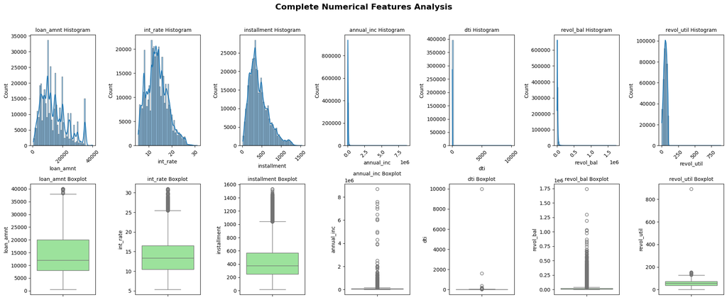

```python
# Univairate Analysis - Numerical columns

num_cols = [ 'loan_amnt', 'int_rate', 'installment','annual_inc', 'dti', 'revol_bal', 'revol_util']

fig, axes = plt.subplots(2 , 7, figsize=(20,8))

# Top row: Histograms
for idx, col in enumerate(num_cols):
    sns.histplot(data=df, x=col, kde=True, bins=50, ax=axes[0, idx])
    axes[0, idx].set_title(f'{col} Histogram', fontsize=10)
    axes[0, idx].tick_params(axis='x', rotation=45)

# Bottom row: Boxplots
for idx, col in enumerate(num_cols):
    sns.boxplot(data=df, y=col, ax=axes[1, idx], color='lightgreen')
    axes[1, idx].set_title(f'{col} Boxplot', fontsize=10)
    axes[1, idx].tick_params(axis='x', rotation=45)

plt.suptitle('Complete Numerical Features Analysis', fontsize=16, fontweight='bold', y=1.02)
plt.tight_layout()
plt.show()
```

### Insights

1. **Loan amount, installment, and income are heavily right-skewed**, indicating that most borrowers take moderate loans while a small fraction takes very large exposures.
2. **Installment closely mirrors loan amount**, confirming it is a derived variable and should not be treated as an independent risk driver.
3. **Annual income shows extreme outliers**, suggesting the presence of ultra-high earners that can disproportionately influence the model if not capped.
4. **DTI has a long tail with extreme values**, highlighting borrowers with very high leverage who are inherently riskier.
5. **Revolving balance and utilization exhibit significant outliers**, indicating potential over-dependence on revolving credit for a subset of borrowers.
6. Overall, **most numerical features require scaling and outlier treatment** before being used in logistic regression.

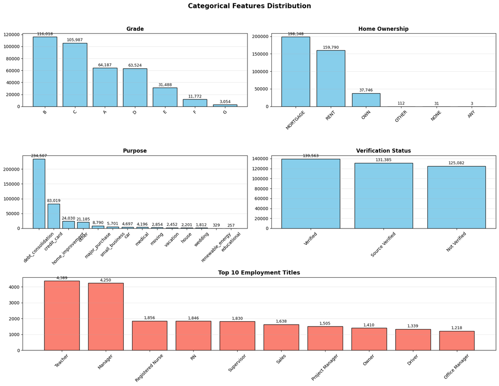

```python
# Univariate Analysis - Categorical columns (clean layout)

cat_cols_main = ['grade', 'home_ownership', 'purpose', 'verification_status']
emp_col = 'emp_title'

fig = plt.figure(figsize=(16, 12))
gs = fig.add_gridspec(3, 2)

# ---- First 4 categorical variables ----
for idx, col in enumerate(cat_cols_main):
    ax = fig.add_subplot(gs[idx // 2, idx % 2])
    value_counts = df[col].value_counts()

    bars = ax.bar(value_counts.index, value_counts.values,
                  color='skyblue', edgecolor='black')

    for bar in bars:
        height = bar.get_height()
        ax.text(bar.get_x() + bar.get_width()/2.,height + 0.01 * value_counts.max(),f'{int(height):,}',ha='center', va='bottom', fontsize=9)

    ax.set_title(col.replace('_', ' ').title(),fontsize=12, fontweight='bold')
    ax.tick_params(axis='x', rotation=45)
    ax.grid(axis='y', alpha=0.3)

# ---- emp_title (last row, full width) ----
ax_emp = fig.add_subplot(gs[2, :])

# IMPORTANT: show only top N job titles
top_n = 10
emp_counts = df[emp_col].value_counts().head(top_n)

bars = ax_emp.bar(emp_counts.index, emp_counts.values,color='salmon', edgecolor='black')

for bar in bars:
    height = bar.get_height()
    ax_emp.text(bar.get_x() + bar.get_width()/2.,height + 0.01 * emp_counts.max(),f'{int(height):,}',ha='center', va='bottom', fontsize=9)

ax_emp.set_title('Top 10 Employment Titles',fontsize=13, fontweight='bold')
ax_emp.tick_params(axis='x', rotation=45)
ax_emp.grid(axis='y', alpha=0.3)

plt.suptitle('Categorical Features Distribution',fontsize=15, fontweight='bold', y=1.02)

plt.tight_layout()
plt.show()
```

### Insights

1. **Credit grades are skewed toward mid-risk borrowers (Grades B and C)**, indicating LoanTap’s portfolio is concentrated in moderate-risk segments rather than extreme low- or high-risk customers.
2. **Home ownership is dominated by MORTGAGE and RENT (~90% combined)**, suggesting most borrowers have ongoing housing liabilities, which is an important factor in repayment stress.
3. **Debt consolidation is the most common loan purpose by a large margin**, highlighting that borrowers primarily use personal loans to manage existing debt rather than discretionary spending.
4. **Verification status is fairly evenly distributed across categories**, implying that income verification alone is not a strong differentiator and must be combined with other financial indicators.
5. **Employment titles show a long-tail distribution with few dominant roles (Teacher, Manager)**, reinforcing why `emp_title` is unsuitable for modeling due to high cardinality but useful for descriptive insights.

### 5.2 Bivariate Analysis

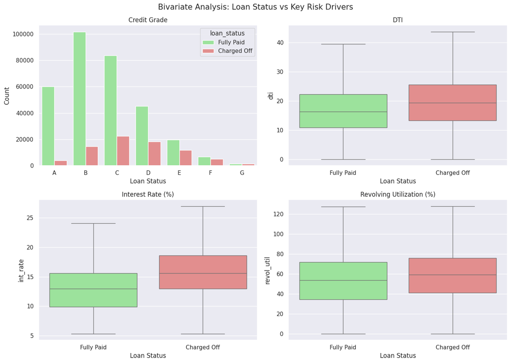

```python
sns.set(style="darkgrid")
palette = {'Fully Paid': 'lightgreen', 'Charged Off': 'lightcoral'}

plots = [
    ('count', 'grade', None, 'Credit Grade'),
    ('box', 'dti', None, 'DTI'),
    ('box', 'int_rate', None, 'Interest Rate (%)'),
    ('box', 'revol_util', None, 'Revolving Utilization (%)')
]

fig, axes = plt.subplots(2, 2, figsize=(14, 10))
fig.suptitle('Bivariate Analysis: Loan Status vs Key Risk Drivers', fontsize=15)

for ax, (ptype, y, _, title) in zip(axes.flat, plots):
    if ptype == 'count':
        sns.countplot( x=y, hue='loan_status', data=df,order=sorted(df[y].unique()),palette=palette, ax=ax)
        ax.set_ylabel('Count')
    elif ptype == 'box':
        sns.boxplot(x='loan_status', y=y, data=df,palette=palette, showfliers=False, ax=ax)
    else:
        sns.boxplot(x='loan_status', y=y, data=df,palette=palette, inner='quartile', ax=ax)

    ax.set_title(title)
    ax.set_xlabel('Loan Status')

plt.tight_layout()
plt.show()
```

### Insights

1. **Credit grade provides the strongest class separation**, with default risk increasing steadily from Grade C onward.
2. **Defaulters have higher DTI**, indicating weaker affordability and higher leverage.
3. **Interest rates are higher for charged-off loans**, confirming effective risk-based pricing.
4. **Revolving utilization is elevated among defaulters**, reflecting financial stress.
5. **No single feature fully separates outcomes**, justifying a multivariate ML approach.

## 6. Correlation Analysis

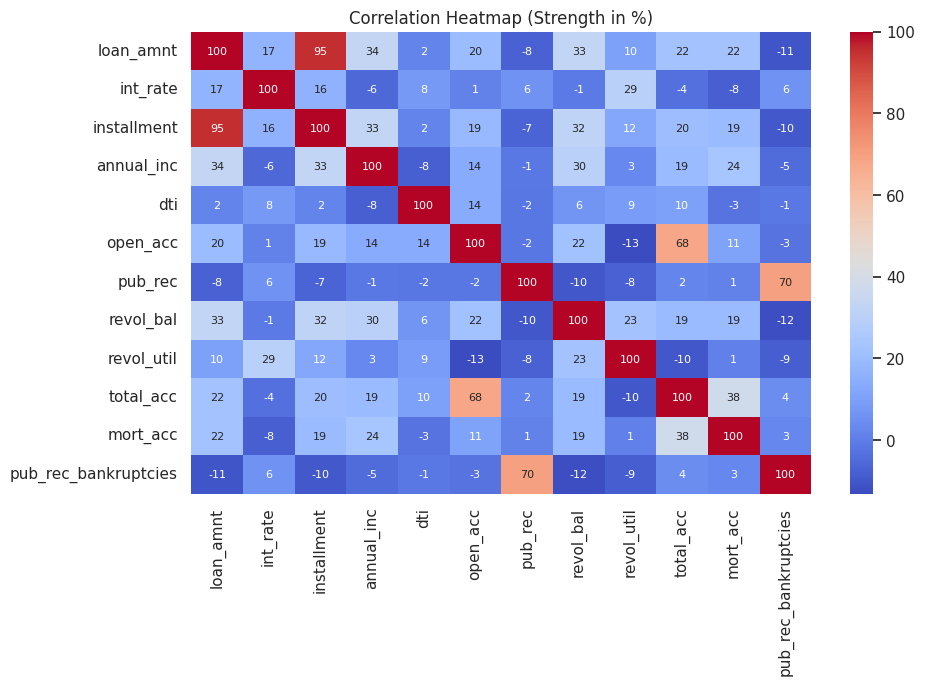

```python
# Correlation on numeric features only
corr_pct = df.select_dtypes(include=np.number).corr() * 100

plt.figure(figsize=(10, 6))
sns.heatmap(
    corr_pct,
    cmap='coolwarm',
    annot=True,
    fmt='.0f',
    annot_kws={'size': 8}
)
plt.title('Correlation Heatmap (Strength in %)')
plt.show()
```

### Insights

1. **Loan amount and installment are highly correlated (~95%)**, so installment is redundant.
2. **Open accounts and total accounts (~68%)**, and **public records with bankruptcies (~70%)** show strong overlap and can be consolidated.
3. **DTI and interest rate show low correlation with other variables**, indicating they add independent risk signal.
4. **Most features are weakly correlated**, supporting the use of a multivariate ML model.

## 7. Data Preprocessing

### 7.1 Missing Value Treatment

```python
missing_values_df = df.isnull().sum().sort_values(ascending=False)
missing_values_df.head(10)
```

|  | 0 |
| --- | --- |
| mort_acc | 37795 |
| emp_title | 22927 |
| emp_length | 18301 |
| title | 1756 |
| pub_rec_bankruptcies | 535 |
| revol_util | 276 |
| installment | 0 |
| int_rate | 0 |
| term | 0 |
| grade | 0 |

**dtype:** int64

```python
df.drop(columns=['emp_title', 'title'], inplace=True)
df[['mort_acc', 'pub_rec_bankruptcies']] = df[['mort_acc', 'pub_rec_bankruptcies']].fillna(0)
df['revol_util'].fillna(df['revol_util'].median(), inplace=True)
```

```python
# Clean & convert emp_length to numeric
df['emp_length'] = ( df['emp_length'] .replace({'10+ years': '10', '< 1 year': '0', '1 year': '1'})
    .astype(str).str.extract('(\d+)').astype(float))

df['emp_length'].fillna(df['emp_length'].median(), inplace=True)
df['emp_length'] = pd.cut(df['emp_length'],bins=[-1, 1, 4, 7, 10], labels=[0, 1, 2, 3]).astype(int)
#encoding done for modelling later
```

### 7.2 Outlier Treatment

```python
# Numerical columns prone to outliers
outlier_cols = [
    'loan_amnt',
    'annual_inc',
    'dti',
    'revol_bal',
    'revol_util'
]

for col in outlier_cols:
  lower, upper = df[col].quantile([0.01,0.99])
  df[col] = df[col].clip(lower=lower, upper=upper)
```

## 8. Feature Engineering , Selection and Encoding

```python
df_model = df.copy()
```

```python
df_model['loan_status'] = df_model['loan_status'].map({'Fully Paid': 1,'Charged Off': 0}).astype(int)
df_model['issue_d'] = pd.to_datetime(df['issue_d'])
df_model['earliest_cr_line'] = pd.to_datetime(df['earliest_cr_line'])

df_model['loan_age_months'] = (df_model['issue_d'].max() - df_model['issue_d']).dt.days // 30

df_model['credit_history_years'] = (df_model['issue_d'] - df_model['earliest_cr_line']).dt.days // 365
df_model['term_months'] = (df_model['term'].str.replace(' months','').astype(int))
```

```python
df_model['pub_rec_flag'] = (df['pub_rec'] > 0).astype(int)
df_model['mort_acc_flag'] = (df['mort_acc'] > 0).astype(int)
df_model['bankruptcy_flag'] = (df['pub_rec_bankruptcies'] > 0).astype(int)
```

```python
grade_map = {'A':1,'B':2,'C':3,'D':4,'E':5,'F':6,'G':7}
df_model['sub_grade_enc'] = (df_model['sub_grade'].str[0].map(grade_map) * 10 +df_model['sub_grade'].str[1].astype(int))

verify_map = {'Not Verified': 0,'Source Verified': 1,'Verified': 2}
df_model['verification_enc'] = df_model['verification_status'].map(verify_map)

df_model.drop(columns=['verification_status'], inplace=True)
```

```python
df_model['initial_list_status_enc'] = (df_model['initial_list_status'] == 'w').astype(int)
df_model['application_type_enc'] = (df_model['application_type'] == 'Joint').astype(int)

df_model.drop(columns=['initial_list_status','application_type'], inplace=True)
```

```python
df_model['home_ownership'] = df_model['home_ownership'].replace(['ANY','NONE','OTHER'], 'OTHER')

df_model = pd.get_dummies(
    df_model,
    columns=['home_ownership'],
    drop_first=True
)
```

```python
drop_cols = [
    'address',          # leakage
    'zip_code',         # leakage (if exists)
    'grade',            # redundant with sub_grade
    'loan_amnt',        # redundant with installment (keep EMI)
    'pub_rec',          # replaced by flag
    'mort_acc',         # replaced by flag
    'pub_rec_bankruptcies'  # replaced by flag
]

df_model.drop(columns=[c for c in drop_cols if c in df_model.columns],
              inplace=True)
df_model.drop(columns=['issue_d','earliest_cr_line'], errors='ignore', inplace=True)
df_model.drop(columns=['term'], inplace=True)
df_model.drop(columns=['sub_grade'], inplace=True)
df_model.drop(columns=['open_acc'], inplace=True)
```

```python
top_purpose = df_model['purpose'].value_counts().nlargest(5).index
df_model['purpose'] = np.where(df_model['purpose'].isin(top_purpose),df_model['purpose'],'OTHER')

df_model = pd.get_dummies(
    df_model,
    columns=['purpose'],
    drop_first=True
)
```

```python
# No strings allowed
assert df_model.select_dtypes(include='object').shape[1] == 0

# Drop near-constant columns
low_var = [c for c in df_model.columns if df_model[c].nunique() <= 1]
df_model.drop(columns=low_var, inplace=True)
```

### Insights and Reasoning

- **Target variable encoding** converts loan outcomes into a binary format (1 = Fully Paid, 0 = Charged Off), enabling logistic regression to directly model default probability while maintaining clear business interpretation.
- **Temporal features** such as loan_age_months and credit_history_years capture borrower maturity and exposure over time, which are more informative and less leakage-prone than raw date fields.
- **Risk flags** (pub_rec_flag, mort_acc_flag, bankruptcy_flag) simplify rare but high-impact credit events into binary indicators, improving model stability and interpretability over raw count variables.
- **Ordinal encoding** of sub_grade and verification_status preserves their inherent risk hierarchy, allowing the model to learn monotonic risk patterns aligned with real underwriting logic.
- **Dimensional control and leakage prevention** were enforced by dropping high-cardinality text fields, redundant features (e.g., grade vs sub-grade, loan amount vs installment), and near-constant variables, resulting in a clean, fully numeric, logistic-ready dataset.

## 9. Model building - Logisitic regression

```python
X = df_model.drop('loan_status', axis=1)
y = df_model['loan_status']


scaler = StandardScaler()
X_scaled = scaler.fit_transform(X)


X_train, X_test, y_train, y_test = train_test_split(
    X_scaled,
    y,
    test_size=0.2,
    stratify=y,
    random_state=42
)


model = LogisticRegression(
    max_iter=1000,
    class_weight='balanced',   # critical for NPA control
    solver='liblinear'
)

model.fit(X_train, y_train)
```

```
LogisticRegression(class_weight='balanced', max_iter=1000, solver='liblinear')
```

### Insights and Explanation

- **After separating features and target, scaling inputs, and performing a stratified 80–20 train–test split**, a class-balanced logistic regression model was trained to handle data imbalance and focus on default risk rather than majority-class accuracy.

### Model Design and Assumptions

Logistic Regression was selected as the baseline model due to its **high interpretability**, which is critical for credit underwriting and regulatory transparency.

Key modeling decisions include:

- **StandardScaler** was applied to normalize numerical features, ensuring stable optimization and enabling meaningful comparison of model coefficients.
- The dataset exhibited class imbalance (~80% fully paid vs ~20% defaulters). To address this, `class_weight='balanced'` was used so that the model assigns higher importance to the minority (defaulter) class.
- A **stratified train-test split** was implemented to preserve the original class distribution across training and testing sets.

While further hyperparameter tuning could marginally improve performance, the primary objective was to establish a **robust, interpretable baseline model** suitable for real-world deployment rather than over-optimizing metrics.

## 10. Model Evaluation and interpretation

```python
# ===================== MODEL EVALUATION ===================== #

from sklearn.metrics import (classification_report,confusion_matrix,roc_auc_score,roc_curve,precision_recall_curve,average_precision_score)

# Predictions
y_pred = model.predict(X_test)
y_prob = model.predict_proba(X_test)[:, 1]   # P(Fully Paid)

print("Classification Report (Default Threshold = 0.5)")
print(classification_report(y_test, y_pred))

print("ROC AUC:", round(roc_auc_score(y_test, y_prob), 4))

# Confusion Matrix
cm = confusion_matrix(y_test, y_pred)
print("Confusion Matrix (rows=true, cols=predicted):")
print(cm)
```

```
Classification Report (Default Threshold = 0.5)
              precision    recall  f1-score   support

           0       0.32      0.63      0.42     15535
           1       0.88      0.67      0.76     63671

    accuracy                           0.66     79206
   macro avg       0.60      0.65      0.59     79206
weighted avg       0.77      0.66      0.70     79206

ROC AUC: 0.7072
Confusion Matrix (rows=true, cols=predicted):
[[ 9789  5746]
 [20866 42805]]
```

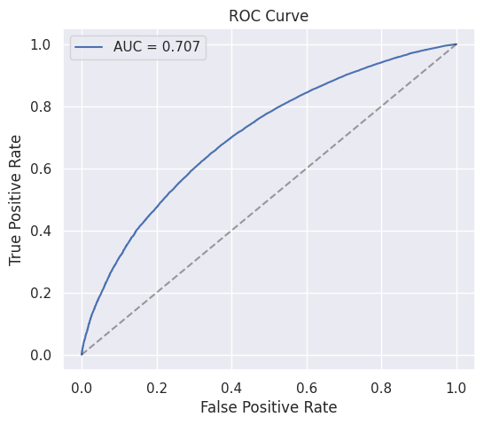

```python
# ===================== ROC CURVE ===================== #

fpr, tpr, _ = roc_curve(y_test, y_prob)

plt.figure(figsize=(6,5))
plt.plot(fpr, tpr, label=f'AUC = {roc_auc_score(y_test, y_prob):.3f}')
plt.plot([0,1], [0,1], 'k--', alpha=0.4)
plt.xlabel('False Positive Rate')
plt.ylabel('True Positive Rate')
plt.title('ROC Curve')
plt.legend()
plt.show()
```

### ROC Curve Analysis

The ROC-AUC score of approximately **0.71** indicates that the model has a **reasonable ability to distinguish** between borrowers who will repay and those who may default.

```
Average Precision (Defaulter as Positive): 0.3662
```

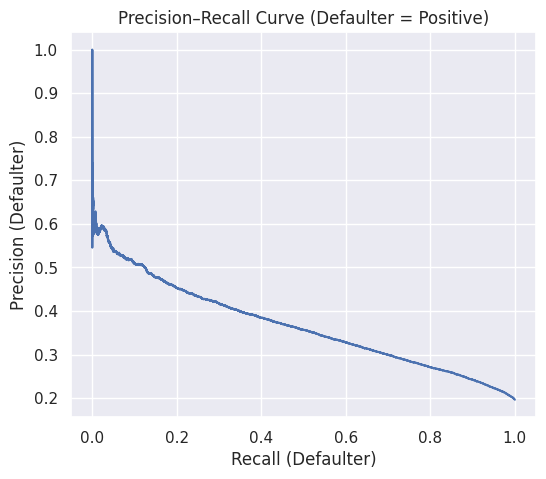

```python
# ===================== PRECISION-RECALL (DEFAULTER AS POSITIVE) ===================== #

# Convert to default probability
default_prob = 1 - y_prob

prec, rec, thr = precision_recall_curve(y_test == 0, default_prob)
ap = average_precision_score(y_test == 0, default_prob)

print("Average Precision (Defaulter as Positive):", round(ap, 4))

plt.figure(figsize=(6,5))
plt.plot(rec, prec)
plt.xlabel('Recall (Defaulter)')
plt.ylabel('Precision (Defaulter)')
plt.title('Precision–Recall Curve (Defaulter = Positive)')
plt.show()
```

### Precision–Recall Tradeoff and Threshold Optimization

Given the business priority of minimizing NPAs, the **defaulter class** was treated as the positive class during precision–recall analysis.

```python
# ===================== COEFFICIENT INTERPRETATION ===================== #

coef_df = (pd.DataFrame({'feature': X.columns,'coefficient': model.coef_[0]})
          .sort_values(by='coefficient', ascending=False)
          .reset_index(drop=True))

print("Top features increasing probability of FULLY PAID:")
display(coef_df.head(10))

print("Top features increasing probability of DEFAULT:")
display(coef_df.tail(10).sort_values(by='coefficient', ascending=False))
```

```
Top features increasing probability of FULLY PAID:
```

|  | feature | coefficient |
| --- | --- | --- |
| 0 | annual_inc | 0.172414 |
| 1 | int_rate | 0.093561 |
| 2 | loan_age_months | 0.086886 |
| 3 | bankruptcy_flag | 0.066433 |
| 4 | purpose_credit_card | 0.059325 |
| 5 | mort_acc_flag | 0.050482 |
| 6 | purpose_debt_consolidation | 0.050372 |
| 7 | revol_bal | 0.049763 |
| 8 | total_acc | 0.034611 |
| 9 | emp_length | 0.021479 |

```
Top features increasing probability of DEFAULT:
```

|  | feature | coefficient |
| --- | --- | --- |
| 15 | credit_history_years | -0.015934 |
| 16 | verification_enc | -0.033060 |
| 17 | home_ownership_OWN | -0.036951 |
| 18 | pub_rec_flag | -0.080349 |
| 19 | installment | -0.089319 |
| 20 | revol_util | -0.089375 |
| 21 | home_ownership_RENT | -0.113675 |
| 22 | term_months | -0.197633 |
| 23 | dti | -0.201832 |
| 24 | sub_grade_enc | -0.568817 |

### Business Interpretation of Classification Metrics

The classification report and confusion matrix were analyzed from a business perspective:

- **False Negatives (missed defaulters)** represent direct financial loss and contribute to higher NPAs.
- **False Positives (rejected good borrowers)** represent opportunity cost in terms of lost interest income and customer acquisition.

In the baseline model:

- Defaulter recall is approximately **63%**, indicating that a majority of risky borrowers are correctly identified.
- Defaulter precision is approximately **32%**, reflecting a conservative screening strategy.

This trade-off is acceptable in a credit underwriting context, where **risk containment takes precedence over aggressive loan disbursement**, especially in early-stage decision systems.

```python
# ===================== DECILE ANALYSIS ===================== #

df_eval = pd.DataFrame({'y_true': y_test.values,'p_fully_paid': y_prob})

df_eval['p_default'] = 1 - df_eval['p_fully_paid']

df_eval['decile'] = pd.qcut(df_eval['p_default'],10,labels=False,duplicates='drop')

decile_summary = (df_eval.groupby('decile').agg(
        p_default_mean=('p_default', 'mean'),
        default_rate=('y_true', lambda x: 1 - x.mean()),
        count=('y_true', 'count')
    ).reset_index().sort_values('p_default_mean', ascending=False))

display(decile_summary)
```

|  | decile | p_default_mean | default_rate | count |
| --- | --- | --- | --- | --- |
| 9 | 9 | 0.784604 | 0.442747 | 7921 |
| 8 | 8 | 0.661046 | 0.329924 | 7920 |
| 7 | 7 | 0.581979 | 0.269915 | 7921 |
| 6 | 6 | 0.520762 | 0.217172 | 7920 |
| 5 | 5 | 0.467723 | 0.184573 | 7921 |
| 4 | 4 | 0.418575 | 0.157576 | 7920 |
| 3 | 3 | 0.371964 | 0.131675 | 7921 |
| 2 | 2 | 0.324751 | 0.100379 | 7920 |
| 1 | 1 | 0.272807 | 0.079914 | 7921 |
| 0 | 0 | 0.198922 | 0.047469 | 7921 |

## Insights and Explanation

### Overall Model Performance

Rather than focusing on accuracy—which is not meaningful in an imbalanced lending dataset—the evaluation emphasizes the model’s ability to **rank borrowers by risk**, which is the primary requirement for credit underwriting systems.

### Defaulter Detection Effectiveness

The model achieves a **defaulter recall of approximately 63%**, indicating that a significant portion of risky borrowers are successfully identified. This is critical from a lending perspective, as missed defaulters directly contribute to **non-performing assets (NPAs)**.

At the same time, defaulter precision is approximately **32%**, reflecting a deliberate and conservative trade-off. This means that while some creditworthy borrowers may be flagged as risky, the model prioritizes **risk prevention over aggressive loan approvals**, which is appropriate in early-stage or high-risk lending environments.

### Key Risk Drivers Identified

Analysis of model coefficients highlights several features that strongly influence repayment behavior:

The direction and strength of these relationships align closely with established credit underwriting principles, reinforcing both **model interpretability** and **business confidence** in the results.

### Business Application and Policy Recommendations

The model should be deployed as a **probability-based decision engine** rather than a fixed approval rule.

A practical underwriting strategy would involve:

- **Low-risk borrowers**: Auto-approval
- **Medium-risk borrowers**: Approval with tighter terms or manual review
- **High-risk borrowers**: Rejection or additional verification requirements

Decision thresholds should be **periodically recalibrated** based on portfolio performance, risk appetite, and macroeconomic conditions to ensure a balanced approach between growth and risk control.

### Final Takeaway

Overall, the model demonstrates strong alignment between **statistical performance and real-world lending objectives**. Its ability to rank risk, identify key default drivers, and support policy-based decisioning makes it suitable for deployment as a foundational underwriting tool, with scope for further enhancement through additional data and ongoing monitoring.

```python
print("Thanks for reading")
```

```
Thanks for reading
```